# Assignment 7

T Xu

Wednesday, October 01, 2014

## Loading in your data set

This lab introduces you to portfolio theory. Let us get started by loading the returns_df data set into your workspace. This data set contains the returns on the Boeing and Microsoft stock from 1992-07-01 up to 2000-10-01. You can find the data set at http://s3.amazonaws.com/assets.datacamp.com/course/compfin/lab8.RData.

```r
# Load relevant packages
library("PerformanceAnalytics")
library("zoo")
source("portfolio.r", keep.source=FALSE)
# Load the data
load(url("http://s3.amazonaws.com/assets.datacamp.com/course/compfin/lab8.RData"))
# Explore the data set
head(returns_df)
```

```
##              rboeing    rmsft
## 1992-07-01  0.003134  0.03854
## 1992-08-01 -0.071233  0.02375
## 1992-09-01 -0.013509  0.07746
## 1992-10-01 -0.020623  0.09758
## 1992-11-01 -0.024602  0.04811
## 1992-12-01  0.133085 -0.08689
```

```r
tail(returns_df)
```

```
##             rboeing   rmsft
## 2000-05-01 -0.01221 -0.1088
## 2000-06-01  0.06803  0.2459
## 2000-07-01  0.15479 -0.1362
## 2000-08-01  0.09721  0.0000
## 2000-09-01  0.18436 -0.1463
## 2000-10-01  0.05008  0.1328
```

## The CER model

A quick recap on the constant expected return model (CER) as seen in the previous chapter: $Rit=μi+ϵit, t=1,…,T ϵit ~ iid N(0,σ2i) cov(ϵ_it,ϵ_jt)=σij$, where Rit denotes the continuously compounded return on asset i, now with i= Microsoft and Boeing. As discussed in the previous chapter, the parameters μi, σi and ρij are unknown to us. However, you can estimate the model parameters for both the Boeing and the Microsoft stock based on the data in returns_df.

```r
# The returns_df data is preloaded in your workspace

# Estimate the parameters: multivariate
mu_hat_annual = apply(returns_df,2,mean)*12
sigma2_annual = apply(returns_df,2,var)*12
sigma_annual = sqrt(sigma2_annual)
cov_mat_annual = cov(returns_df)*12
cov_hat_annual = cov(returns_df)[1,2]*12
rho_hat_annual = cor(returns_df)[1,2]

# The annual estimates of the CER model parameters for Boeing and Microsoft
mu_boeing = mu_hat_annual["rboeing"]
mu_msft = mu_hat_annual["rmsft"]
sigma2_boeing =  sigma2_annual["rboeing"]
sigma2_msft = sigma2_annual["rmsft"]
sigma_boeing = sigma_annual["rboeing"]
sigma_msft = sigma_annual["rmsft"]
sigma_boeing_msft = cov_hat_annual
rho_boeing_msft = rho_hat_annual
```

## A portfolio of Boeing and Microsoft stock

In this exercise, you will create a set of portfolios that consist of Microsoft and Boeing stock. The goal is to visualize all these portfolios in a plot with on the x-axis the portfolio standard deviation and on the y-axis the expected return on the portfolio. The code on the right specifies the vector boeing_weights. Every element of the vector boeing_weights represents the proportion of Boeing stocks for that portfolio. The set of weights for Boeing that you will consider ranges from -1, -0.9, …, up to 2.

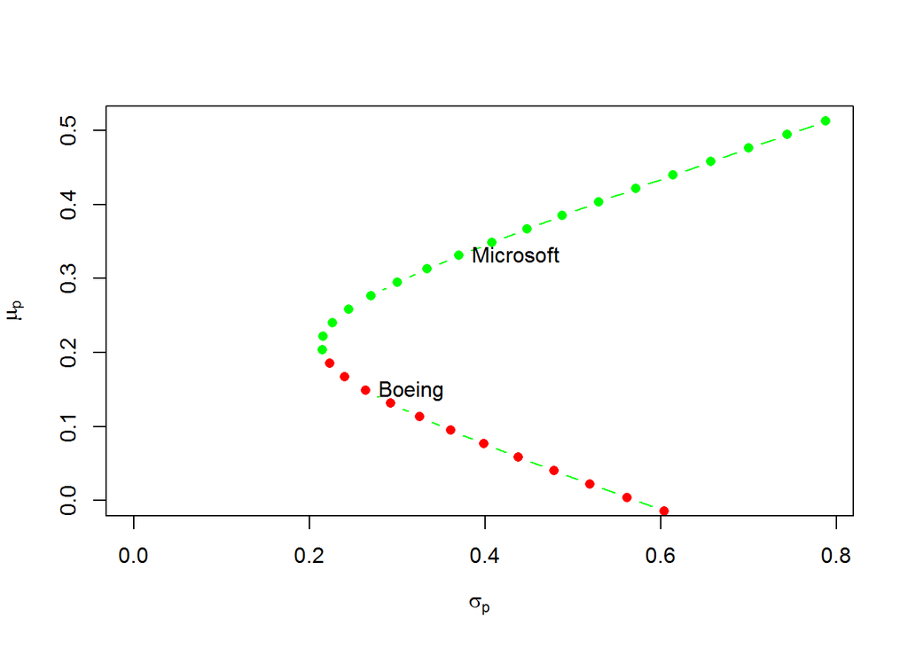

```r
# All data and CER parameters are preloaded in your workspace.
# Type "ls()" in the console to see them.

# The ratio Boeing stock vs Microsoft stock (adds up to 1)
boeing_weights = seq(from=-1, to=2, by=0.1)
msft_weights = seq(from=2, to=-1, by=-0.1)

# Portfolio parameters
mu_portfolio =  boeing_weights*mu_boeing + msft_weights*mu_msft

sigma2_portfolio =  boeing_weights^2 * sigma2_boeing + msft_weights^2 * sigma2_msft + 2*boeing_weights*msft_weights*sigma_boeing_msft

sigma_portfolio = sqrt(sigma2_portfolio)


# Plotting the different portfolios
plot(sigma_portfolio, mu_portfolio, type="b", pch=16, ylim=c(0, max(mu_portfolio)), xlim=c(0, max(sigma_portfolio)), xlab=expression(sigma[p]), ylab=expression(mu[p]),col=c(rep("green", 18), rep("red", 13)))
text(x=sigma_boeing, y=mu_boeing, labels="Boeing", pos=4)
text(x=sigma_msft, y=mu_msft, labels="Microsoft", pos=4)
```

## Adding T-bills to your portfolios

As seen in the lectures, you can potentially increase the performance of your portfolio significantly by investing in T-bills as well. Use an annual risk-free rate of 3% per year for the T-billand and create a set of portfolios with the T-bills and the Boeing stock as underlying assets. Again, you are allowed to take short positions in both assets.

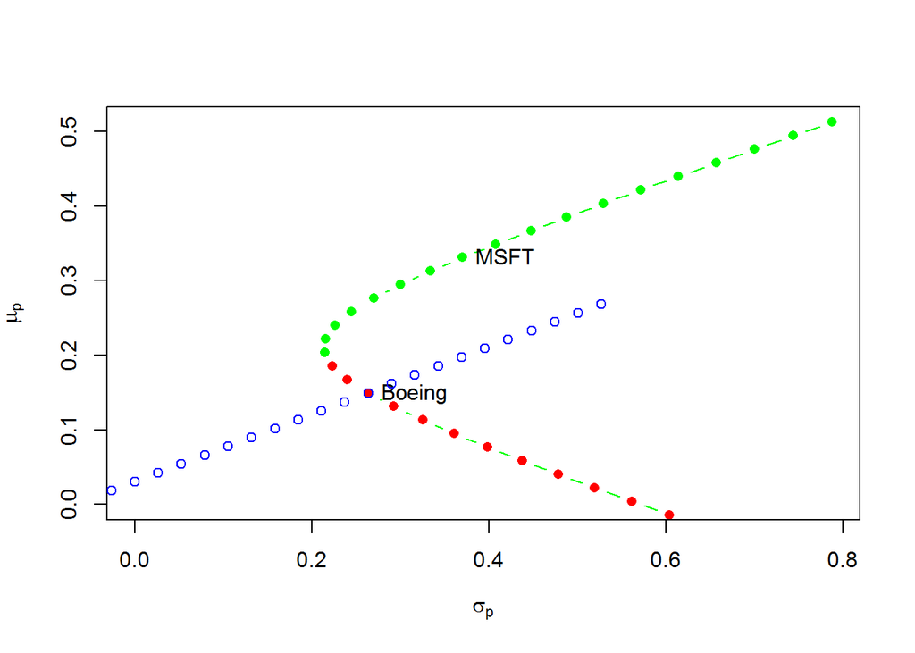

```r
# All data and CER parameters are preloaded in your workspace.
# Type "ls()" in the console to see them.

# Annual risk-free rate of 3% per year for the T-bill
t_bill_rate = 0.03

# Ratio Boeing stocks
boeing_weights = seq(from=-1, to=2, by=0.1)

# Portfolio parameters
mu_portfolio_boeing_bill = t_bill_rate + boeing_weights*(mu_boeing - t_bill_rate)

sigma_portfolio_boeing_bill = boeing_weights*sigma_boeing

# Plot previous exercise
plot(sigma_portfolio, mu_portfolio, type="b", pch=16, ylim=c(0, max(mu_portfolio)), xlim=c(0, max(sigma_portfolio)), xlab=expression(sigma[p]), ylab=expression(mu[p]),col=c(rep("green", 18), rep("red", 13)))
text(x=sigma_boeing, y=mu_boeing, labels="Boeing", pos=4)
text(x=sigma_msft, y=mu_msft, labels="MSFT", pos=4)

# Portfolio Combination Boeing and T-bills
points(sigma_portfolio_boeing_bill, mu_portfolio_boeing_bill, type="b", col="blue")
```

The Sharpe Slope ———————– Having a value for the T-bill annual risk-free rate, you can now calculate the Sharpe slope for the Boeing stock.

```r
# All data and CER parameters are preloaded in your workspace.
# Type "ls()" in the console to see them.

# Sharp ratio Boeing
sharp_ratio_boeing = (mu_boeing - t_bill_rate)/sigma_boeing
```

## Global Minimum Variance Portfolio

The global minimum variance portfolio is the portfolio that provides you with the lowest possible portfolio volatility for a number of underlying assets. To calculate the global minimum variance portfolio for our returns_df data set, you can make use of the R function globalMin.portfolio(). The globalMin.portfolio() function only needs two inputs: The er argument: the expected returns of the underlying assets (that is mu_hat_annual in this case). The cov.mat argument: the covariance matrix of the returns (that is cov_mat_annual in this case). Both mu_hat_annual and cov_mat_annual were calculated in a previous exercise and are preloaded in your workspace.

```r
# All data and CER parameters are preloaded in your workspace.
# Type "ls()" in the console to see them.
globalMin.portfolio <- function(er, cov.mat)
{
  # Compute global minimum variance portfolio
  #
  # inputs:
  # er              N x 1 vector of expected returns
  # cov.mat     N x N return covariance matrix
  #
  # output is portfolio object with the following elements
  # call            original function call
  # er              portfolio expected return
  # sd              portfolio standard deviation
  # weights     N x 1 vector of portfolio weights
  call <- match.call()

  #
  # check for valid inputs
  #
  asset.names <- names(er)
  er <- as.vector(er)                   # assign names if none exist
  cov.mat <- as.matrix(cov.mat)
  if(length(er) != nrow(cov.mat))
    stop("invalid inputs")
  if(any(diag(chol(cov.mat)) <= 0))
    stop("Covariance matrix not positive definite")
  # remark: could use generalized inverse if cov.mat is positive semi-definite

  #
  # compute global minimum portfolio
  #
  cov.mat.inv <- solve(cov.mat)
  one.vec <- rep(1,length(er))
#  w.gmin <- cov.mat.inv %*% one.vec/as.vector(one.vec %*% cov.mat.inv %*% one.vec)
  w.gmin <- rowSums(cov.mat.inv) / sum(cov.mat.inv)
  w.gmin <- as.vector(w.gmin)
  names(w.gmin) <- asset.names
  er.gmin <- crossprod(w.gmin,er)
  sd.gmin <- sqrt(t(w.gmin) %*% cov.mat %*% w.gmin)
  gmin.port <- list("call" = call,
            "er" = as.vector(er.gmin),
            "sd" = as.vector(sd.gmin),
            "weights" = w.gmin)
  class(gmin.port) <- "portfolio"
  gmin.port
}
# The global minimum variance portfolio
global_min_var_portfolio = globalMin.portfolio(mu_hat_annual,cov_mat_annual)
global_min_var_portfolio
```

```
## Call:
## globalMin.portfolio(er = mu_hat_annual, cov.mat = cov_mat_annual)
##
## Portfolio expected return:     0.2106
## Portfolio standard deviation:  0.2139
## Portfolio weights:
## rboeing   rmsft
##   0.662   0.338
```

```r
# Summary of global_min_var_portfolio that takes into account the annual risk-free rate of 3% per year
summary(global_min_var_portfolio, risk.free=0.03)
```

```
## Call:
## globalMin.portfolio(er = mu_hat_annual, cov.mat = cov_mat_annual)
##
## Portfolio expected return:     0.2106
## Portfolio standard deviation:  0.2139
## Portfolio Sharpe Ratio:        0.8443
## Portfolio weights:
## rboeing   rmsft
##   0.662   0.338
```

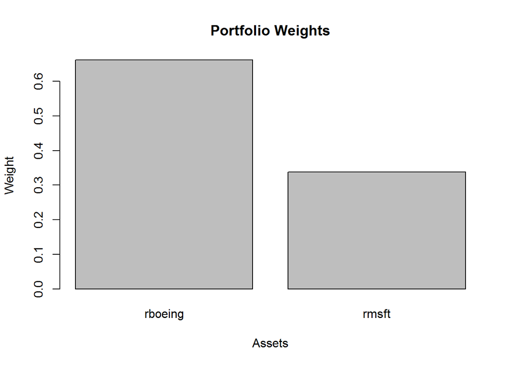

```r
# Portfolio weights Boeing and Microsoft
plot(global_min_var_portfolio)
```

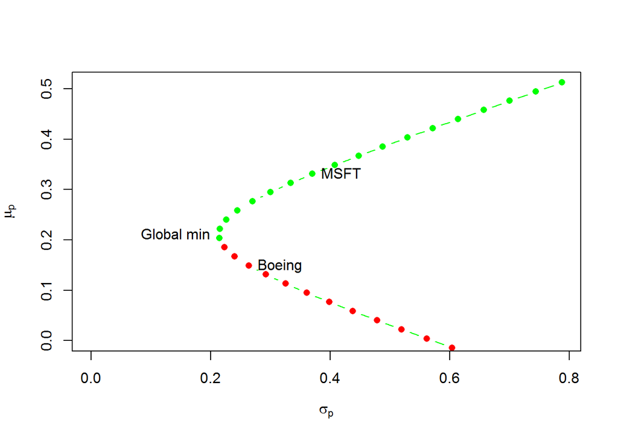

```r
# Plot previous exercises
plot(sigma_portfolio, mu_portfolio, type="b", pch=16, ylim=c(0, max(mu_portfolio)), xlim=c(0, max(sigma_portfolio)), xlab=expression(sigma[p]), ylab=expression(mu[p]),col=c(rep("green", 18), rep("red", 13)))
text(x=sigma_boeing, y=mu_boeing, labels="Boeing", pos=4)
text(x=sigma_msft, y=mu_msft, labels="MSFT", pos=4)

# Plot the position of the global minimum variance portfolio
text(x=global_min_var_portfolio$sd, y=global_min_var_portfolio$er, labels="Global min", pos=2)
```

## Expected return

What is the expected return of the global minimum variable portfolio? Note that all data and CER parameters are preloaded in your workspace. Type ls() in the console to see them.

```r
summary(global_min_var_portfolio)
```

```
## Call:
## globalMin.portfolio(er = mu_hat_annual, cov.mat = cov_mat_annual)
##
## Portfolio expected return:     0.2106
## Portfolio standard deviation:  0.2139
## Portfolio weights:
## rboeing   rmsft
##   0.662   0.338
```

## Tangency Portfolio

The tangency portfolio is the portfolio on the efficient frontier with the highest Sharpe ratio. In this exercise you will calculate the composition of the tangency portfolio, taking into account investment options in Boeing and Microsoft stock. To do this, you will make use of the tangency.portfolio() function. More specifically, tangency.portfolio() has the arguments: er: the expected returns (mu_hat_annual) cov.mat: the covariance matrix of the returns (cov_mat_annual) risk.free: the risk-free rate (3% in this case).

```r
# All data and CER parameters are preloaded in your workspace.
# Type "ls()" in the console to see them.
tangency.portfolio <-
function(er,cov.mat,risk.free)
{
  # compute tangency portfolio
  #
  # inputs:
  # er                 N x 1 vector of expected returns
  # cov.mat        N x N return covariance matrix
  # risk.free        scalar, risk-free rate
  #
  # output is portfolio object with the following elements
  # call              captures function call
  # er                portfolio expected return
  # sd                portfolio standard deviation
  # weights      N x 1 vector of portfolio weights
  call <- match.call()

  #
  # check for valid inputs
  #
  asset.names <- names(er)
  if(risk.free < 0)
    stop("Risk-free rate must be positive")
  er <- as.vector(er)
  cov.mat <- as.matrix(cov.mat)
  if(length(er) != nrow(cov.mat))
    stop("invalid inputs")
  if(any(diag(chol(cov.mat)) <= 0))
    stop("Covariance matrix not positive definite")
  # remark: could use generalized inverse if cov.mat is positive semi-definite

  #
  # compute global minimum variance portfolio
  #
  gmin.port <- globalMin.portfolio(er,cov.mat)
  if(gmin.port$er < risk.free)
    stop("Risk-free rate greater than avg return on global minimum variance portfolio")

  #
  # compute tangency portfolio
  #
  cov.mat.inv <- solve(cov.mat)
  w.t <- cov.mat.inv %*% (er - risk.free) # tangency portfolio
  w.t <- as.vector(w.t/sum(w.t))    # normalize weights
  names(w.t) <- asset.names
  er.t <- crossprod(w.t,er)
  sd.t <- sqrt(t(w.t) %*% cov.mat %*% w.t)
  tan.port <- list("call" = call,
           "er" = as.vector(er.t),
           "sd" = as.vector(sd.t),
           "weights" = w.t)
  class(tan.port) <- "portfolio"
  tan.port
}
# The tangency portfolio
tangency_portfolio = tangency.portfolio(mu_hat_annual, cov_mat_annual,risk.free=0.03)
tangency_portfolio
```

```
## Call:
## tangency.portfolio(er = mu_hat_annual, cov.mat = cov_mat_annual,
##     risk.free = 0.03)
##
## Portfolio expected return:     0.2507
## Portfolio standard deviation:  0.2365
## Portfolio weights:
## rboeing   rmsft
##  0.4409  0.5591
```

```r
# Summary of tangency_portfolio with annual risk free rate of 3%
summary(tangency_portfolio ,risk.free=0.03)
```

```
## Call:
## tangency.portfolio(er = mu_hat_annual, cov.mat = cov_mat_annual,
##     risk.free = 0.03)
##
## Portfolio expected return:     0.2507
## Portfolio standard deviation:  0.2365
## Portfolio Sharpe Ratio:        0.9334
## Portfolio weights:
## rboeing   rmsft
##  0.4409  0.5591
```

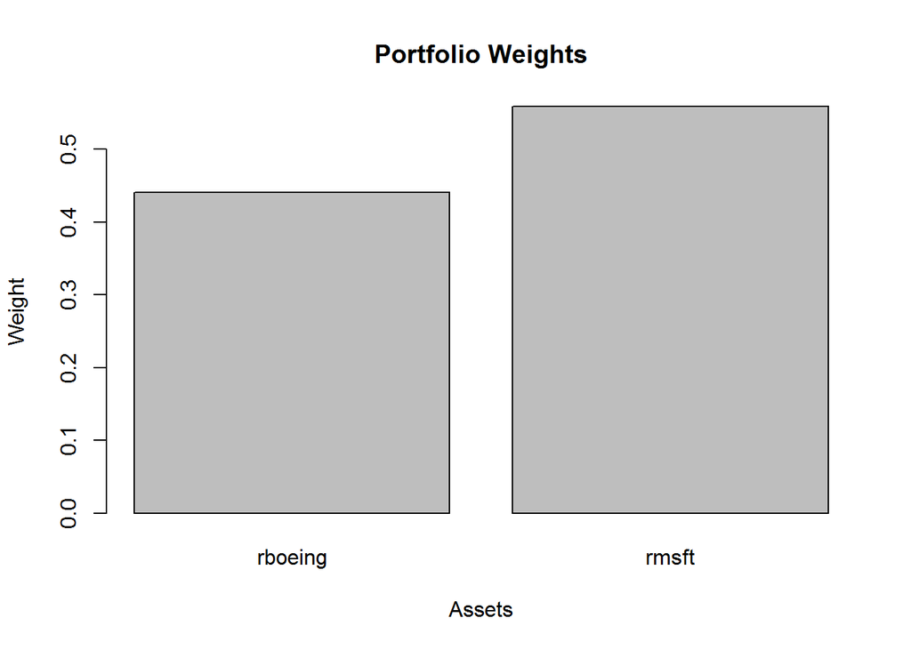

```r
# Portfolio weights Boeing and Microsoft
plot(tangency_portfolio)
```

Tangency portfolio and T-bills —————————— In the previous exercise, you calculated the composition of the tangency portfolio. As a second step, you create new portfolios that are a combination of T-bills and this tangency portfolio. First, you will need to compute the expected portfolio return and volatility for these portfolios. Second, your job is to create a plot of these portfolios with the volatility on the x-axis and the expected return on the y-axis.

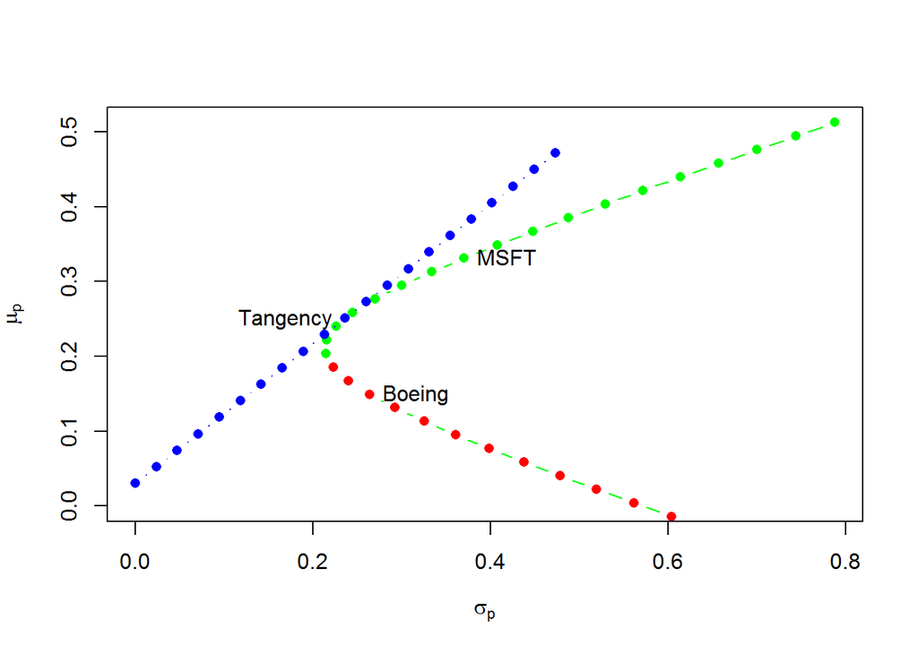

```r
# All data and CER parameters are preloaded in your workspace.
# Type "ls()" in the console to see them.

# Annual risk-free rate of 3% per year for the T-bill
t_bill_rate = 0.03

# Set of tangency portfolio weights
tangency_weights = seq(from=0, to=2, by=0.1)

# Portfolio parameters
mu_portfolio_tangency_bill = t_bill_rate + tangency_weights*(tangency_portfolio$er-t_bill_rate)
sigma_portfolio_tangency_bill = tangency_weights*tangency_portfolio$sd

# Plot previous exercises
plot(sigma_portfolio, mu_portfolio, type="b", pch=16, ylim=c(0, max(mu_portfolio)), xlim=c(0, max(sigma_portfolio)), xlab=expression(sigma[p]), ylab=expression(mu[p]),col=c(rep("green", 18), rep("red", 13)))
text(x=sigma_boeing, y=mu_boeing, labels="Boeing", pos=4)
text(x=sigma_msft, y=mu_msft, labels="MSFT", pos=4)

# Plot portfolio combinations of tangency portfolio and T-bills
text(x=tangency_portfolio$sd, y=tangency_portfolio$er, labels="Tangency", pos=2)
points(sigma_portfolio_tangency_bill, mu_portfolio_tangency_bill, type="b", col="blue", pch=16)
```

An Efficient Portfolio with 30% Tangency —————————————– Consider a portfolio that has 30% invested in the tangency portfolio and 70% in T-bills. Before making the final call, you want to investigate this portfolio’s return and volatility in more detail. You decide to use the techniques that you learned in the previous exercises to map the portfolio in the spectrum of available portfolios.

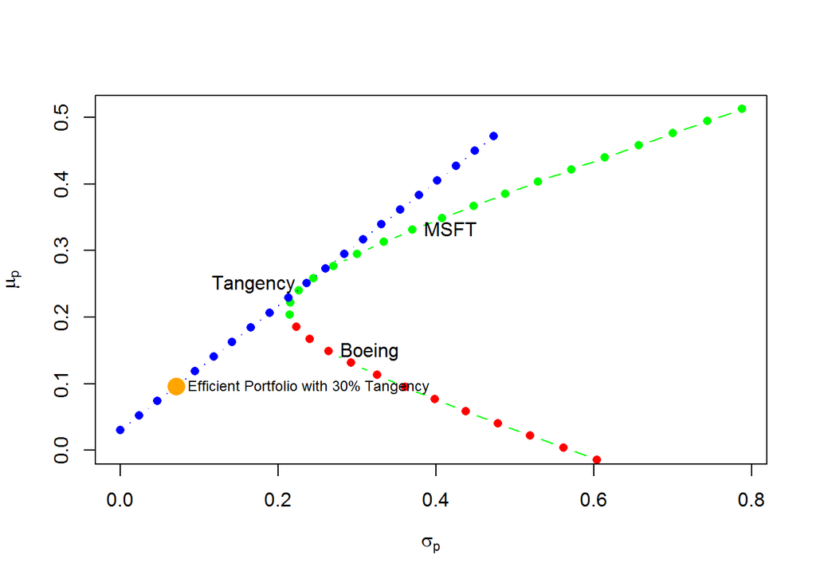

```r
# All data and CER parameters are preloaded in your workspace.
# Type "ls()" in the console to see them.

# Define the portfolio ratio's
tangency_weight = 0.3
t_bill_weight = 1 - tangency_weight

# Define the portfolio parameters
mu_portfolio_efficient = t_bill_rate + tangency_weight*(tangency_portfolio$er - t_bill_rate)
sd_portfolio_efficient = tangency_weight*tangency_portfolio$sd

# Plot previous exercises
plot(sigma_portfolio, mu_portfolio, type="b", pch=16, ylim=c(0, max(mu_portfolio)), xlim=c(0, max(sigma_portfolio)), xlab=expression(sigma[p]), ylab=expression(mu[p]),col=c(rep("green", 18), rep("red", 13)))
text(x=sigma_boeing, y=mu_boeing, labels="Boeing", pos=4)
text(x=sigma_msft, y=mu_msft, labels="MSFT", pos=4)
text(x=tangency_portfolio$sd, y=tangency_portfolio$er, labels="Tangency", pos=2)
points(sigma_portfolio_tangency_bill, mu_portfolio_tangency_bill, type="b", col="blue", pch=16)

# Plot Efficient Portfolio with 30% Tangency
points(sd_portfolio_efficient, mu_portfolio_efficient, type="p", col="orange", pch=16, cex=2)
text(x=sd_portfolio_efficient, y=mu_portfolio_efficient, labels="Efficient Portfolio with 30% Tangency", pos=4, cex=0.75)
```

An Efficient Portfolio with the SD of Boeing —————————– In this final exercise, you want to find the efficient portfolio (combination of T-bills and tangency portfolio) that has the same risk (SD) as Boeing.

[figure not shown]

```r
# All data and CER parameters are preloaded in your workspace.
# Type "ls()" in the console to see them.

# Define the tangency portfolio ratio
tangency_weight  = sigma_boeing/tangency_portfolio$sd

# Calculate the weight of the tangency portfolio in the portfolio
mu_portfolio_efficient = t_bill_rate + tangency_weight*(tangency_portfolio$er - t_bill_rate)
sd_portfolio_efficient = tangency_weight*tangency_portfolio$sd

# Plot previous exercises
plot(sigma_portfolio, mu_portfolio,bg="NA", type="b", pch=16, ylim=c(0, max(mu_portfolio)), xlim=c(0, max(sigma_portfolio)), xlab=expression(sigma[p]), ylab=expression(mu[p]),col=c(rep("green", 18), rep("red", 13)))
text(x=sigma_boeing, y=mu_boeing, labels="Boeing", pos=4)
text(x=sigma_msft, y=mu_msft, labels="MSFT", pos=4)
text(x=tangency_portfolio$sd, y=tangency_portfolio$er, labels="Tangency", pos=2)
points(sigma_portfolio_tangency_bill, mu_portfolio_tangency_bill, type="b", col="blue", pch=16)

# Plot Efficient Portfolio with the same risk as Boeing
points(sd_portfolio_efficient, mu_portfolio_efficient, type="p", col="orange", pch=16, cex=2)
text(x=sd_portfolio_efficient, y=mu_portfolio_efficient, labels="Efficient Portfolio with same risk as Boeing", pos=2, cex=0.75)
```

## Assignment 8: R

## Question 1

10. What is the Sharpe slope of Boeing?

```r
sharp_ratio_boeing = (mu_boeing - t_bill_rate)/sigma_boeing
```

## Question 2

10. What is the Sharpe slope of Microsoft?

```r
sharp_ratio_msft = (mu_msft - t_bill_rate)/sigma_msft
```

## Question 3

10. What is the Sharpe slope of the global minimum variance portfolio?

```r
global_min_var_portfolio
```

```
## Call:
## globalMin.portfolio(er = mu_hat_annual, cov.mat = cov_mat_annual)
##
## Portfolio expected return:     0.2106
## Portfolio standard deviation:  0.2139
## Portfolio weights:
## rboeing   rmsft
##   0.662   0.338
```

```r
(global_min_var_portfolio$er-t_bill_rate)/global_min_var_portfolio$sd
```

```
## [1] 0.8443
```

## Question 4

10. What is the Sharpe slope of the tangency portfolio?

```r
tangency_portfolio
```

```
## Call:
## tangency.portfolio(er = mu_hat_annual, cov.mat = cov_mat_annual,
##     risk.free = 0.03)
##
## Portfolio expected return:     0.2507
## Portfolio standard deviation:  0.2365
## Portfolio weights:
## rboeing   rmsft
##  0.4409  0.5591
```

```r
(0.2507215-0.03)/0.2364756
```

```
## [1] 0.9334
```

## Question 5

10. What is the Sharpe slope of a portfolio that has 10% in the tangency portfolio and 90% in T-bills? same as Q4

## Question 6

10. What is the Sharpe slope of the efficient portfolio (combination of T-bills and tangency portfolio) that has the same risk (SD) as Microsoft? same as Q4

## Question 7

10. What is the portfolio weight of Microsoft in the global minimum variance portfolio?

```r
global_min_var_portfolio$weights
```

```
## rboeing   rmsft
##   0.662   0.338
```

## Question 8

10. What is the portfolio weight of Microsoft in the tangency portfolio?

```r
tangency_portfolio$weights
```

```
## rboeing   rmsft
##  0.4409  0.5591
```

## Question 9

10. What is the expected return of the efficient portfolio (combination of T-bills and tangency portfolio) that has the same risk (SD) as Microsoft?

```r
0.9334 * sigma_msft + 0.03
```

```
##  rmsft
## 0.3754
```

## Question 10

10. For the efficient portfolio (combination of T-bills and tangency portfolio) that has the same risk (SD) as Microsoft, what is the percentage of wealth invested into T-bills?